# 8. Mantenimiento de motores 4T

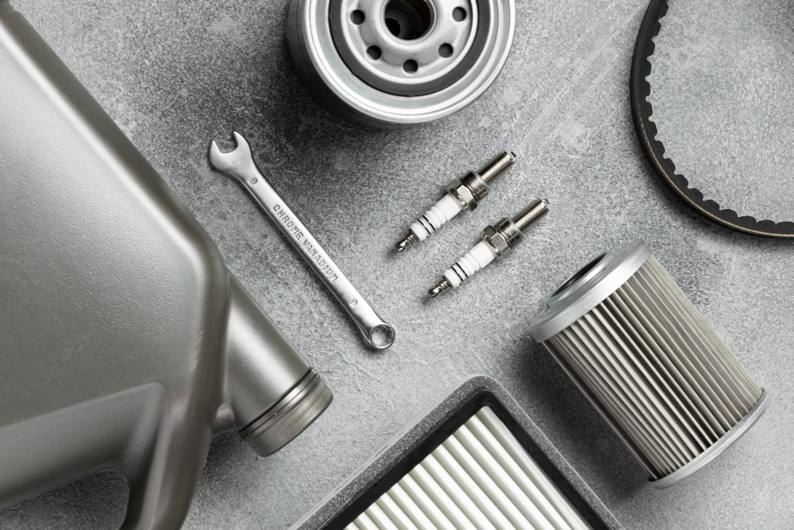

Fuente: autoland.com.pe

## Tipos de mantenimiento

El mantenimiento permite que el motor funcione correctamente, dure más y evite fallas graves.

### Mantenimiento preventivo

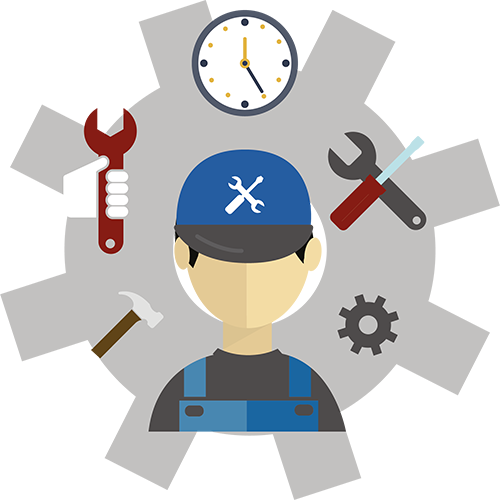

Se hace cada cierto tiempo o km - Fuente: eribertodeolivera.com

Son tareas que se hacen **antes de que algo falle**, para prolongar la vida útil del motor.

- **Cambio de aceite**: cada cierta cantidad de horas o kilómetros.
- **Limpieza o cambio del filtro de aire**.
- **Limpieza o cambio de bujía**.
- **Revisión de cables, tornillos, correas, mangueras**.
- **Revisión del sistema de refrigeración (nivel de agua o estado del radiador)**.
- **Ajuste de válvulas** (si aplica).
- **Chequeo de consumo de combustible**.

### Mantenimiento correctivo

[figure not shown]

Se hace cuando algo ha fallado - Fuente: rimsamex.com

Se realiza **cuando algo ya está fallando**.

- Reemplazo de partes desgastadas o rotas.
- Reparación del sistema de encendido, carburación o lubricación.
- Ajustes importantes cuando el motor pierde potencia, se traba o no arranca.

### Mantenimiento predictivo (básico en taller)

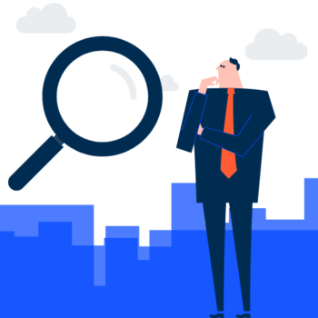

Implica observar y predecir la falla. Puede implicar mediciones sofisticadas como conteo de partículas en el aceite. - Fuente: cegid.com

Consiste en **anticipar fallas** observando ciertos **síntomas comunes**:

| Síntoma | Posible causa |
| --- | --- |
| Humo blanco o azul | Problemas con aceite o junta de tapa |
| Ruido metálico | Desgaste interno, falta de lubricación |
| Motor caliente o se apaga | Problemas de refrigeración |
| Dificultad para arrancar | Bujía sucia, carburador, batería baja |
| Consumo excesivo de combustible | Mezcla mal regulada, filtro sucio |

## Actividad 1

Siempre es importante consultar el manual del vehículo o máquina en cuestión. El manual da las pautas que son la base para hacer el mantenimiento. Por ejemplo dice que tipo de aceite usar. El manual más común es el **“manual del usuario”** que trae datos básicos. También está el **manual de taller o de servicio** que trae datos más especializados y es el que los mecánicos normalmente usan.

Busca el manual de usuario de una maquina o vehículo con motor de 4T al que tengas acceso. Puede ser un grupo electrógeno, una moto, un auto, etc. Escribe un lista de al menos 5 mantenimientos preventivos que nombre el manual. Por ejemplo el manual puede decir en el caso de una moto: Lavar filtro de aire cada 3000 Km. A veces traen una tabla con un conjunto de cosas que hay que hacer cada cierto periodo.

## Actividad 2

Busca un video en el que se explique como hacer un cambio de aceite en algún motor 4T. Escribe el paso a paso que se sigue. Por ejemplo el primer paso suele ser encender el motor unos minutos para que el aceite se caliente y fluya mejor.

## Actividad 3

Investiga en que consiste el mantenimiento preventivo llamado “regulación o ajuste de válvulas”. Busca algún video explicativo si quieres. Luego detalla **para que sirve** y **describe** brevemente el procedimiento.